# R Notebook

```r
library(corrplot)
library(ggplot2)

library(readxl)
library(mongolite)
library(sqldf)
library(isotree)
library(Rlof)
library(lubridate)
library(mice)
library(tidyverse)
```

# Carga de bases

```r
#dir igal
# df_artist <- read.csv("C:/Users/igalk/OneDrive/Documentos/laburo/Data Mining FCEyN/Data mining/TP/data_mining/data/df_artist_sin_duplicados.csv")
#
# #borrado de duplicados que quedaron
#
# # #
# df_charts <- read.csv("C:/Users/igalk/OneDrive/Documentos/laburo/Data Mining FCEyN/Data mining/TP/data_mining/data/df_charts_sin_duplicados.csv")
# # #
# df_audio_features <- read.csv("C:/Users/igalk/OneDrive/Documentos/laburo/Data Mining FCEyN/Data mining/TP/audio_features_plano_sin_duplicados.csv")


#dir Nacho
#df_artist <- read.csv()

#df_charts <- read.csv()

#df_audio_features <- read.csv()

#dir Mateo
df_artist <- read.csv("data/df_artist_sin_duplicados.csv")
df_charts <- read.csv("data/df_charts_sin_duplicados.csv")
df_audio_features <- read.csv("data/audio_features_plano_sin_duplicados.csv")

#borro duplicados que quedaron en el aurio_features
#queda listo para el join con chrats
df_audio_features <- df_audio_features %>%
  group_by(track_name, external_urls_spotify) %>%
  mutate(artist_all = paste(artist_name, collapse = ",|,")) %>%
  ungroup() %>%
  mutate(artist_key = sub(",|,.*", "", artist_all)) %>%
  select(artist_name, artist_all, artist_key, everything(.)) %>%
  distinct(artist_key, external_urls_spotify, .keep_all = T) %>%
  as.data.frame()
```

```
      artist_name artist_all artist_key acousticness album_id album_name album_release_date
89207           1          1          1            1        1          1                  1
59920           1          1          1            1        1          1                  1
113             1          1          1            1        1          1                  1
300             1          1          1            1        1          1                  1
                0          0          0            0        0          0                  0
      album_release_date_precision album_type analysis_url artist_id danceability disc_number duration_ms energy
89207                            1          1            1         1            1           1           1      1
59920                            1          1            1         1            1           1           1      1
113                              1          1            1         1            1           1           1      1
300                              1          1            1         1            1           1           1      1
                                 0          0            0         0            0           0           0      0
      explicit external_urls_spotify instrumentalness is_local key key_mode key_name liveness loudness mode
89207        1                     1                1        1   1        1        1        1        1    1
59920        1                     1                1        1   1        1        1        1        1    1
113          1                     1                1        1   1        1        1        1        1    1
300          1                     1                1        1   1        1        1        1        1    1
             0                     0                0        0   0        0        0        0        0    0
      mode_name speechiness tempo time_signature track_href track_id track_name track_number track_uri type
89207         1           1     1              1          1        1          1            1         1    1
59920         1           1     1              1          1        1          1            1         1    1
113           1           1     1              1          1        1          1            1         1    1
300           1           1     1              1          1        1          1            1         1    1
              0           0     0              0          0        0          0            0         0    0
      valence artist_concat markets_concat album_release_year track_preview_url
89207       1             1              1                  1                 1     0
59920       1             1              1                  1                 0     1
113         1             1              1                  0                 1     1
300         1             1              1                  0                 0     2
            0             0              0                413             60220 60633
```

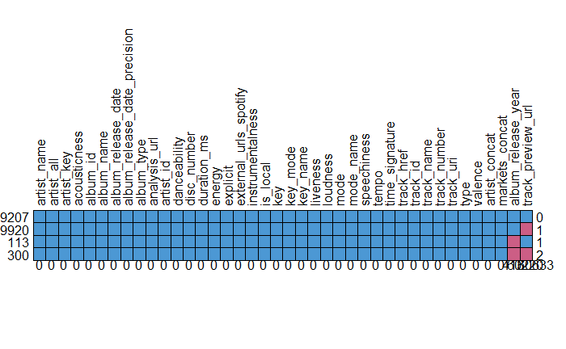

```r
#Análisis de NA
md.pattern(df_audio_features, rotate.names = TRUE) #faltan dos columas irrelevantes
```

```
 /\     /\
{  `---'  }
{  O   O  }
==>  V <==  No need for mice. This data set is completely observed.
 \  \|/  /
  `-----'

      Position Track_Name Artist Streams URL week_start week_end concatenated_id
31404        1          1      1       1   1          1        1               1 0
             0          0      0       0   0          0        0               0 0
```

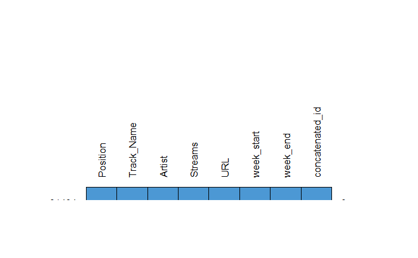

```r
md.pattern(df_charts, rotate.names = TRUE)
```

```r
#md.pattern(df_artist, rotate.names = TRUE) #no tiene sentido con 1 sola columna
```

#Analisis de semanas y mercados

```r
#chequeo de semanas: tenemos 157 semanas en total, 200 temas por semana
df_charts %>% mutate(week_number = week(week_start),
                     anio = year(week_start),
                     week_anio = paste(anio,week_number, sep = "-")) %>%
  select(week_start, week_number, anio, week_anio) %>%
  group_by(week_anio) %>%
  summarise(n = n())
```

| week_anio | n |
| --- | --- |
| 2018-10 | 200 |
| 2018-11 | 200 |
| 2018-12 | 200 |
| 2018-13 | 200 |
| 2018-14 | 200 |
| 2018-15 | 200 |
| 2018-16 | 200 |
| 2018-17 | 200 |
| 2018-18 | 200 |
| 2018-19 | 200 |

[output cut: 147 more lines]

```r
#armo columna con cantidad de paises donde está disponible cada canción

contar_market <- function(x){
q <- length(unlist(strsplit(x, split = ",")))
return (q)
  }
df_audio_features$cant_markets <- sapply(df_audio_features[,"markets_concat"], contar_market)

summary(df_audio_features$cant_markets) #hay canciones en cero países. Están dadas de baja
```

```
   Min. 1st Qu.  Median    Mean 3rd Qu.    Max.
    0.0    22.0   173.0   117.5   178.0   178.0
```

```r
# df_audio_features[order(-df_audio_features$cant_markets),"cant_markets"]


# head(df_audio_features[1:300,], 300)
```

#vectores de features

```r
#features var continuos
features_continuas <- c('acousticness', 'danceability', 'duration_ms', 'energy', 'instrumentalness', 'liveness', 'loudness', 'speechiness',   'tempo', 'valence', 'cant_markets')

#features var_ categóricas
features_categoricas <- c('explicit', 'key_name', 'mode_name', "key_mode", "album_type", "markets_concat", "artist_concat")
```

#Join audio features y charts

```r
#Armamos un join para tener una tabla de charts con las caracteristicas de las canciones
# deberian quedar 22993 filas completas
join_audio_charts <- df_audio_features %>%
  select("artist_name","artist_all","artist_key",
         "track_name", "external_urls_spotify",
         features_continuas, features_categoricas,
         "album_release_date","album_release_date_precision","album_release_year") %>%
  right_join( df_charts %>%
               select( "Track_Name", "Artist",
                       "URL","Position", "Streams", "week_start", "week_end"),
               by = c(
                 "track_name" = "Track_Name",
                      "artist_key" ="Artist",
                      "external_urls_spotify" = "URL"))
```

[output not shown]

```
      artist_key track_name external_urls_spotify Position Streams week_start week_end artist_name artist_all
19110          1          1                     1        1       1          1        1           1          1
6              1          1                     1        1       1          1        1           1          1
12288          1          1                     1        1       1          1        1           0          0
               0          0                     0        0       0          0        0       12288      12288
      acousticness danceability duration_ms energy instrumentalness liveness loudness speechiness tempo valence
19110            1            1           1      1                1        1        1           1     1       1
6                1            1           1      1                1        1        1           1     1       1
12288            0            0           0      0                0        0        0           0     0       0
             12288        12288       12288  12288            12288    12288    12288       12288 12288   12288
      cant_markets explicit key_name mode_name key_mode album_type markets_concat artist_concat album_release_date
19110            1        1        1         1        1          1              1             1                  1
6                1        1        1         1        1          1              1             1                  1
12288            0        0        0         0        0          0              0             0                  0
             12288    12288    12288     12288    12288      12288          12288         12288              12288
      album_release_date_precision album_release_year
19110                            1                  1      0
6                                1                  0      1
12288                            0                  0     23
                             12288              12294 282630
```

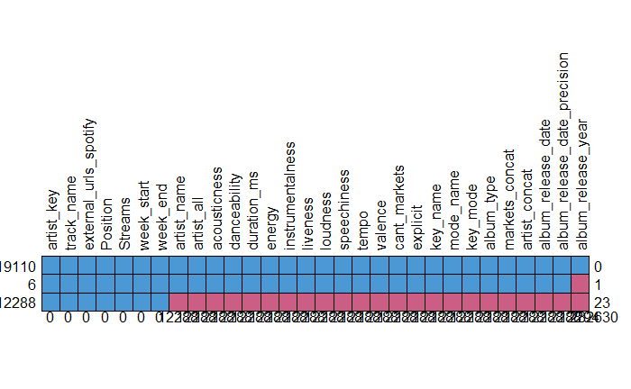

```r
x <- nrow(df_charts)- nrow(join_audio_charts)

#Análisis de NA
md.pattern(join_audio_charts, rotate.names = TRUE) #HAY CHARTS QUE NO TIENEN FEATURES. HAY QUE TENERLO EN CUENTA PARA EL ANÁLISIS
```

```r
## ¿Cuánto tiempo tardan los temas en entrar en el chart desde su fecha de lanzamiento?
```

## evolucion de los streams

```
Ignoring unknown aesthetics: label
```

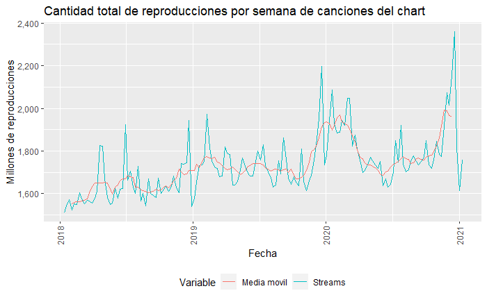

```r
library(vars)
df_charts %>%
   mutate(week_start=as.Date(week_start)) %>%
  group_by(week_start) %>%
  summarise(reproductions = sum(Streams)) %>%
  ggplot(aes(week_start, reproductions/10^6, color = "k", label = "Streams") )+
  geom_line()+
  geom_line(aes(x= week_start,y= rollmean(reproductions/10^6, 8, na.pad = T), color = "darkblue" , label = "Media movil" )  )+
  # geom_point()+
  theme(axis.text.x = element_text(angle = 90, vjust = 0.5, hjust=1),
        legend.position = "bottom")+
  labs(title = "Cantidad total de reproducciones por semana de canciones del chart",
       x = "Fecha", y ="Millones de reproducciones", fill = "Variable")+
  scale_y_continuous(labels = scales::comma)+
  scale_color_discrete(name = "Variable", labels = c("Media movil", "Streams"))
```

```r
#agregar media movil
# cuanto duran los temas en el top 1 ??
```

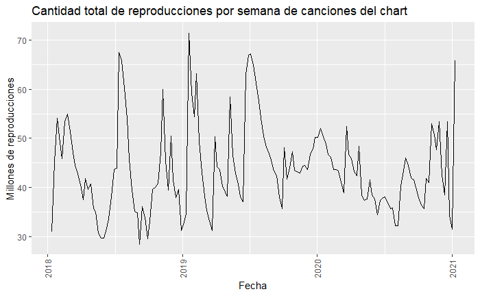

```r
df_charts %>%
   mutate(week_start=as.Date(week_start)) %>%
  filter(Position == 1 ) %>%
  group_by(week_start) %>%
  summarise(reproductions = sum(Streams)) %>%
  ggplot(aes(week_start, reproductions/10^6))+
  geom_line()+
  # geom_point()+
  theme(axis.text.x = element_text(angle = 90, vjust = 0.5, hjust=1))+
  labs(title = "Cantidad total de reproducciones por semana de canciones del chart",
       x = "Fecha", y ="Millones de reproducciones")+
  scale_y_continuous(labels = scales::comma)
```

# ¿Cuánto tiempo tardan los temas en entrar en el chart?

```r
x <- df_charts %>%
  mutate(week_start=as.Date(week_start),
         # week_end = as.Date(week_end),
         week_year = (year(week_start))) %>%
  group_by(Artist, Track_Name, URL) %>%
  summarise( day_in = min(week_start),
             year_in = year(day_in)) %>%
  ungroup() %>%
  left_join(df_audio_features %>%
              dplyr::select("artist_key","track_name", "external_urls_spotify",
                    "album_release_date_precision", "album_release_date",,"album_release_year") %>%
              mutate(album_release_date = as.Date(album_release_date)),
            by = c(  "Track_Name"="track_name" ,
                   "Artist"= "artist_key", "URL"=  "external_urls_spotify" )) %>%
  mutate( # tiempo_entrada_dias = day_in - album_release_date,
         tiempo_entrada_dias = case_when(day_in < album_release_date ~ 0,
                                         T ~ as.double(day_in - album_release_date)),
         tiempo_entrada_anio = year_in - year(album_release_date)) %>%
  dplyr::select(Artist, Track_Name, album_release_date_precision,
                    album_release_date, day_in, tiempo_entrada_dias, year_in,tiempo_entrada_anio)
x %>% arrange(-tiempo_entrada_dias)
```

| Artist | Track_Name | album_release_date_precision | album_release_date | day_in | tiempo_entrada_dias | year_in | tiempo_entrada_anio |
| --- | --- | --- | --- | --- | --- | --- | --- |
| Bing Crosby | White Christmas | day | 1942-01-01 | 2018-11-23 | 28085 | 2018 | 76 |
| Elvis Presley | Blue Christmas | day | 1957-10-15 | 2018-11-30 | 22326 | 2018 | 61 |
| Bobby Helms | Jingle Bell Rock | day | 1957-12-02 | 2018-11-23 | 22271 | 2018 | 61 |
| Dean Martin | Baby, It's Cold Outside | day | 1959-01-01 | 2018-12-21 | 21904 | 2018 | 59 |
| Dean Martin | Rudolph The Red-Nosed Reindeer | day | 1959-01-01 | 2018-12-21 | 21904 | 2018 | 59 |
| Dean Martin | Let It Snow! Let It Snow! Let It Snow! | day | 1959-01-01 | 2018-11-30 | 21883 | 2018 | 59 |
| Burl Ives | A Holly Jolly Christmas - Single Version | day | 1965-01-01 | 2020-11-27 | 20419 | 2020 | 55 |
| Andy Williams | It's the Most Wonderful Time of the Year | day | 1963-11-24 | 2018-11-23 | 20088 | 2018 | 55 |
| Brenda Lee | Rockin' Around The Christmas Tree | day | 1964-10-19 | 2018-11-30 | 19765 | 2018 | 54 |
| The Beach Boys | Little Saint Nick - 1991 Remix | day | 1964-11-09 | 2018-12-21 | 19765 | 2018 | 54 |

[output cut: 990 more lines]

```r
NA
```

# ¿Cuánto tarda en alcanzar su pico?

```r
x <- df_charts %>%
  mutate(week_start=as.Date(week_start),
         week_year = (year(week_start))) %>%
  filter(Position == 1) %>%
  group_by(Artist, Track_Name, URL) %>%
  summarise( day_podio = min(week_start),
             year_podio = year(day_podio)) %>%
  ungroup() %>%
  left_join(df_charts %>%
              mutate(week_start=as.Date(week_start) ),
            by = c( "Track_Name" ,"Artist" , "URL" )  ) %>%
  group_by(Artist, Track_Name, URL, day_podio, year_podio) %>%
  summarise( day_in = min(week_start),
             year_in = year(day_in) ) %>%
  ungroup() %>%
  mutate(  tiempo_podio_dias = day_podio - day_in,
         # tiempo_entrada_dias = case_when(day_in < album_release_date ~ 0,
         #                                 T ~ as.double(day_in - album_release_date)),
         tiempo_podio_anio = year_podio - year_in  )
x %>% arrange(-tiempo_podio_dias)
```

| Artist | Track_Name | URL | day_podio | year_podio | day_in | year_in | tiempo_podio_dias | tiempo_podio_anio |
| --- | --- | --- | --- | --- | --- | --- | --- | --- |
| XXXTENTACION | SAD! | https://open.spotify.com/track/3ee8Jmje8o58CHK66QrVC2 | 2018-06-15 | 2018 | 2018-03-16 | 2018 | 91 days | 0 |
| The Weeknd | Blinding Lights | https://open.spotify.com/track/0sf12qNH5qcw8qpgymFOqD | 2020-02-21 | 2020 | 2019-11-29 | 2019 | 84 days | 1 |
| Tones And I | Dance Monkey | https://open.spotify.com/track/1rgnBhdG2JDFTbYkYRZAku | 2019-10-11 | 2019 | 2019-07-19 | 2019 | 84 days | 0 |
| Roddy Ricch | The Box | https://open.spotify.com/track/0nbXyq5TXYPCO7pr3N8S4I | 2020-02-07 | 2020 | 2019-12-13 | 2019 | 56 days | 1 |
| Jawsh 685 | Savage Love (Laxed - Siren Beat) | https://open.spotify.com/track/1xQ6trAsedVPCdbtDAmk0c | 2020-07-31 | 2020 | 2020-06-12 | 2020 | 49 days | 0 |
| 24kGoldn | Mood (feat. iann dior) | https://open.spotify.com/track/3tjFYV6RSFtuktYl3ZtYcq | 2020-09-18 | 2020 | 2020-08-07 | 2020 | 42 days | 0 |
| DaBaby | ROCKSTAR (feat. Roddy Ricch) | https://open.spotify.com/track/7ytR5pFWmSjzHJIeQkgog4 | 2020-05-29 | 2020 | 2020-04-17 | 2020 | 42 days | 0 |
| Mariah Carey | All I Want for Christmas Is You | https://open.spotify.com/track/0bYg9bo50gSsH3LtXe2SQn | 2018-12-21 | 2018 | 2018-11-09 | 2018 | 42 days | 0 |
| Post Malone | Sunflower - Spider-Man: Into the Spider-Verse | https://open.spotify.com/track/3KkXRkHbMCARz0aVfEt68P | 2019-01-04 | 2019 | 2018-12-14 | 2018 | 21 days | 1 |
| Bad Bunny | DÁKITI | https://open.spotify.com/track/47EiUVwUp4C9fGccaPuUCS | 2020-11-06 | 2020 | 2020-10-30 | 2020 | 7 days | 0 |

[output cut: 32 more lines]

```r
NA
```

# ¿Cuánto tiempo están en un chart?

```r
# cantidad de semanas que estuvieron en el chart

df_charts %>%
  mutate(week_start=as.Date(week_start),
         week_end = as.Date(week_end),
         week_year = (year(week_start))) %>%
  arrange(Artist, Track_Name) %>%
  group_by(Artist, Track_Name, URL) %>%
  summarise( day_in = min(week_start),
             year_in = year(day_in),
             day_max = max(week_end),
             year_max = year(day_max),
             duracion_chart_dias = day_max-day_in,
             duracion_chart_anio = year_max - year_in)
```

| Artist | Track_Name | URL | day_in | year_in | day_max | year_max | duracion_chart_dias | duracion_chart_anio |
| --- | --- | --- | --- | --- | --- | --- | --- | --- |
|  |  | https://open.spotify.com/track/0pYacDCZuRhcrwGUA5nTBe | 2020-05-01 | 2020 | 2020-05-29 | 2020 | 28 days | 0 |
| *NSYNC | Merry Christmas, Happy Holidays | https://open.spotify.com/track/15coTBAzEN1bOeipoNDZAR | 2018-12-21 | 2018 | 2020-12-25 | 2020 | 735 days | 2 |
| *NSYNC | Merry Christmas, Happy Holidays | https://open.spotify.com/track/2il7ZxLzVhPxMHNidnsa3I | 2019-12-20 | 2019 | 2019-12-27 | 2019 | 7 days | 0 |
| 13 Organisé | Bande organisée | https://open.spotify.com/track/6YzQOngfcV0W9F8UOTnEEK | 2020-10-09 | 2020 | 2020-10-23 | 2020 | 14 days | 0 |
| 2 Chainz | Bigger Than You (feat. Drake & Quavo) | https://open.spotify.com/track/5S1IUPueD0xE0vj4zU3nSf | 2018-06-15 | 2018 | 2018-07-20 | 2018 | 35 days | 0 |
| 2 Chainz | Rule The World (feat. Ariana Grande) | https://open.spotify.com/track/1R6VwZ8TuHRzxZUxe88n4I | 2019-03-01 | 2019 | 2019-03-08 | 2019 | 7 days | 0 |
| 2 Chainz | Whip (feat. Travis Scott) | https://open.spotify.com/track/6Z4rmc0uujCpl8yXe3yjgI | 2019-03-01 | 2019 | 2019-03-08 | 2019 | 7 days | 0 |
| 21 Savage | 1.5 | https://open.spotify.com/track/2wOXxtHZgRkkrkEbKLzzqs | 2018-12-21 | 2018 | 2018-12-28 | 2018 | 7 days | 0 |
| 21 Savage | a lot | https://open.spotify.com/track/2t8yVaLvJ0RenpXUIAC52d | 2018-12-21 | 2018 | 2019-06-21 | 2019 | 182 days | 1 |
| 21 Savage | all my friends | https://open.spotify.com/track/4paAidoE8VAemwU4jgCc6l | 2018-12-21 | 2018 | 2019-01-11 | 2019 | 21 days | 1 |

[output cut: 990 more lines]

## Evolucion de los temas en el chart desde el momento 0

```r
# indicador de popularidad
popularidad <- df_charts %>%
  group_by(Artist, Track_Name, URL) %>%
  summarise(semanas_sum = n(),
            streams_sum = (sum(Streams, na.rm = T)/10^6 ),
            position_avg = mean(Position, na.rm = T)) %>%
  ungroup() %>%
  mutate(indicador = as.numeric(streams_sum*semanas_sum/position_avg) )
```

[output not shown]

## ¿Qué características tienen las bandas que solo una vez se pudieron meter en el ranking?

```r
# cantidad de bandas que se metieron una sola vez en el ranking
# unique((df_charts %>%
unique((join_audio_charts %>%
  group_by(artist_key) %>%
  # group_by(Artist) %>%
  summarise(n = n()) %>%
  arrange(n) %>%
  filter(n ==1))$artist_key)
```

- evolucion de los temas en el chart a lo largo del tiempo para ver desempeño del artista
- varianza para ver si la composicion de temas del chart va cambiando mucho a lo largo de las semanas
- buscar medida sintetica entre streams y cantidad de semanas. ponderar la cantidad de semanas
- promedio ponderado / indicador de cantidad de semanas / dias en las que están en el chart y cantidad de reproducciones
- armar ponderador entre streams y cantidad de semanas

cantidad de veces por semana que se escucha la cancion y usarlo como ponderador

grafiar la varianza para ver si son siempre los mismos temas de los charts o van cambiando promedio por semana que estan en el charty tene

```r
x %>%
  ungroup() %>%
  group_by(Artist, week_start) %>%
  mutate(Position = min(Position)) %>%
  distinct(Artist, week_start, .keep_all = T)
  # filter(contador > 50)


# df_charts %>%
#   group_by(week_start, Artist) %>%
#   mutate(max_position = min(Position)) %>%
#   ggplot( aes(week_start, max_position, color = Artist))+
#   geom_point()+
#   theme(legend.position = "none")
```

```r
#arreglar este error de carga
df_charts %>%
  filter(Artist %in% c("", "IU")  )
```

# histogramas y barplots de variables

```r
##histograma de las variables continuas de audio_features

for (i in features_continuas){

  hist(df_audio_features[,i], main = paste("Histograma de", i, "(all data)"), xlab = i)
  abline(v = mean(df_audio_features[,i], na.rm = TRUE) , col="red")
  abline(v = median(df_audio_features[,i], na.rm = TRUE) , col="blue")
  legend("topright", legend = c("Media", "Mediana"), col=c("red", "blue"), lty =1)

}

#divido los features por su distribución
features_continuas_media <- c('danceability', 'tempo', 'valence')

features_continuas_mediana <- c('acousticness', 'duration_ms', 'energy', 'instrumentalness', 'liveness', 'loudness', 'speechiness', 'cant_markets')


##histograma de las variables continuas de charts
for (i in c(features_continuas, "Streams")){

  hist(join_audio_charts[,i], main = paste("Histograma de", i,  "(charts)"), xlab = i)
  abline(v = mean(join_audio_charts[,i], na.rm = TRUE) , col="red")
  abline(v = median(join_audio_charts[,i], na.rm = TRUE) , col="blue")

}

#divido features de charts según su distribución
audio_charts_continuas_media <- c('danceability', 'duration_ms', 'valence')

audio_charts_continuas_mediana <- c('acousticness', 'tempo', 'energy', 'instrumentalness', 'liveness', 'loudness', 'speechiness', 'cant_markets', "Streams")


##medidas resumen y barplots de las variables categoricas audio_features
for(i in features_categoricas){
  print(i)
  barplot(sort(table(df_audio_features[,i]),decreasing = T), las=2,
          main = paste("Barplot de", i))
  # pie(table(df_features_categoricos[,i]))
}

#cantidad de veces que aparece cada país (lo sacamos porque na da nada interpretable)
#vector <- unlist(strsplit(df_audio_features[1,"markets_concat"], split = ","))
#x <- table (vector)
#x <- sort(x)
#barplot(x, las=2)
```

```r
hist(df_audio_features[,"duration_ms"], main = paste("Histograma de duration_ms", "(all data)"), xlab = i, breaks = 150)
abline(v = mean(df_audio_features[,"duration_ms"], na.rm = TRUE) , col="red")
abline(v = median(df_audio_features[,"duration_ms"], na.rm = TRUE) , col="blue")
```

# Correlaciones

```r
#análisis de correlación numericas

#correlaciones en audio features
x <- cor(df_audio_features[,c(features_continuas_media, features_continuas_mediana)],  use =  "complete.obs")
corrplot(x, type = "upper", title = "Correlacion de atributos de audio", mar=c(0,0,1,0) )

#correlaciones en charts
x <- cor(join_audio_charts[,c(audio_charts_continuas_media, audio_charts_continuas_mediana)], use =  "complete.obs")
corrplot(x, type = "upper", title = "Correlacion de atributos de los Charts", mar=c(0,0,1,0) )

#chi2 test
tabla_key_album <- table(df_audio_features$key_name, df_audio_features$album_type)
cat("Tabla de contigencia entre key y album type\n")
tabla_key_album
chisq.test(tabla_key_album)
```

# Analisis de outliers

```r
#Outlier univariado

## Metricas de variacion

#coeficiente de variacion audio_features
cat("coeficiente de variacion\n")
cv <- round(apply(df_audio_features[,c(features_continuas_media, features_continuas_mediana)], 2, statip::cv, na_rm = T),2)
sort(cv, decreasing = T)

cat("\ndesvio_standard\n")
desvio_standard <- round(apply(df_audio_features[,c(features_continuas_media, features_continuas_mediana)], 2, sd),2)
desvio_standard[order(names(desvio_standard))]


#coeficiente de variacion charts
cat("coeficiente de variacion\n")
cv <- round(apply(join_audio_charts[,c(audio_charts_continuas_media, audio_charts_continuas_mediana)], 2, statip::cv, na_rm = T),2)
sort(cv, decreasing = T)

cat("\ndesvio_standard\n")
desvio_standard <- round(apply(join_audio_charts[,c(audio_charts_continuas_media, audio_charts_continuas_mediana)], 2, sd, na.rm=TRUE),2)
desvio_standard[order(names(desvio_standard))]
```

## Boxplots (filtrado de outliers de duration_ms y loudness)

```r
#método 1: boxplot. outlier = > 1.5 DIQ

#calculo bigotes para la variable duration
duration.bigote.superior <- boxplot(df_audio_features$duration_ms)$stats[5]
duration.bigote.inferior <- boxplot(df_audio_features$duration_ms)$stats[1]

#observo cuantos temas unicos superan el bigote
length(unique(df_audio_features["track_id"][(df_audio_features$duration_ms > duration.bigote.superior |
                                               df_audio_features$duration_ms < duration.bigote.inferior),]))

#cuanto temas superan el bigote
length(df_audio_features["track_id"][(df_audio_features$duration_ms > duration.bigote.superior |
                                               df_audio_features$duration_ms < duration.bigote.inferior),])
#cuantos artistas
length(unique(df_audio_features["artist_name"][df_audio_features$duration_ms < duration.bigote.inferior,]))

#observo nuevo boxplot con outliers filtados de duration_ms
boxplot(df_audio_features["duration_ms"][df_audio_features["duration_ms"] <= duration.bigote.superior ])

#calculo umbral para loudness
loudness.bigote.inferior <- boxplot(df_audio_features$loudness)$stats[1]

#guardo nuevo dataset filtrado (nro instancias 140k, perdemos 16k registros )
df_audio_features_filtrado <- df_audio_features %>%
  filter(duration_ms <= duration.bigote.superior &
         loudness >= loudness.bigote.inferior)
```

## Normalizacion con z-score

Para que sean comparables y los guardo en un nuevo DF

```r
#método 2: z-score para var que tienden a la normal
#filtro features numericos
df_audio_features_zscore_media <- df_audio_features[,features_continuas_media]

#normalizo z score con las variables que tienden a la normal
for(i in 1:ncol(df_audio_features_zscore_media)){
  df_audio_features_zscore_media[, i] <- (df_audio_features_zscore_media[,i] -                                   mean(df_audio_features_zscore_media[,i]))/(sd(df_audio_features_zscore_media[,i]))
  }

df_audio_features_zscore_media
#normalizo z score modificado las variables que NO tienden a la normal


#analisis de z score
#variable: speechiness
umbral_zscore = 3
df_audio_features[df_audio_features_zscore_media$speechiness> umbral_zscore,] %>%
  select(album_name,artist_name, speechiness ) %>%
  arrange(-speechiness)

#falta z score con mediana

for (i in 1:ncol(df_audio_features_zscore_mediana)){
  med = median(df_audio_features_zscore_mediana[,i], na.rm = T)
  MAD = median(abs(df_audio_features_zscore_mediana[,i] - med), na.rm = T)
  Mi = 0.6745 * (df_audio_features_zscore_mediana[,i] - med) / MAD
  x[abs(Mi) > 3.5,i] = "outlier"
  df_audio_features_zscore_mediana[paste("zscore_",i, sep="")] <- x
}
```

```r
# Configuramos el tamaño del lienzo (ver "par" del paquete graphics)
par(mfrow=c(1, 1), mar=c(5, 12, 4, 2) )

# boxplot(df_audio_features_scale, horizontal = TRUE, las=1, xlab="z-score")
boxplot(df_audio_features_scale, horizontal = TRUE, las=1, xlab="z-score")
```

## LOF

```r
###################################################

#       BORRADO DE ATRIBUTOS REDUNDANTES

################################################

library(caret)
x <- cor(df_audio_features[,c(features_continuas_media, features_continuas_mediana)], use = "complete.obs")
alta.correlacion <- findCorrelation(x, cutoff=0.85, names=TRUE, verbose= TRUE)






###################################################

#                     CPA

################################################
```

```r
#outliers multivariados

#método 1: distancias de lof
df_audio_features_scale$lof_score <- lof(df_audio_features_scale, k=100)
top_lof <- head(df_audio_features_scale[order(df_audio_features_scale$lof_score,decreasing = TRUE),],4)

print(top_lof)
```

## Isolation Forest

```r
#método 2: isolation forest (categóticas y continuas)

#ajusto el modelo
iforest_sample = isolation.forest(df_audio_features_scale, sample_size = 10000, ntrees=100, ndim = 3, random_seed = 13)

#utilzo el metodo predict para calcula el score sobre todos los puntos
df_audio_features_scale$iforest_pred= predict(iforest_sample, df_audio_features_scale)

#que paises identifico?
top_ifores_sample <- head(df_audio_features[order(df_audio_features_scale$iforest_pred,
                                                  decreasing = T),], 10)
print(top_ifores_sample)
```

```r
#método 3: mahalanobis

#audio_features
df_audio_features_mahala <- df_audio_features
vector_medias = colMeans(df_audio_features_mahala[,features_continuas])
matriz_var_cov = cov(df_audio_features_mahala[,features_continuas])

# Creamos una variable con la distancia
df_audio_features_mahala$maha = sqrt(mahalanobis(df_audio_features_mahala[,features_continuas],vector_medias,matriz_var_cov))

# Los registros mas distantes. criterio del bastón partido
top_maha <- head(df_audio_features_mahala[order(df_audio_features_mahala$maha,decreasing = TRUE),],85)
plot(top_maha$maha) #se observa que las distancias se achican mucho a partir de las 85 más distantes al centro
unique(top_maha$artist_name)

table(top_maha$artist_name)

###############################

#charts
#audio_features
join_audio_charts_mahala <- join_audio_charts
vector_medias = colMeans(join_audio_charts_mahala[,features_continuas], na.rm = TRUE)
matriz_var_cov = cov(join_audio_charts_mahala[,features_continuas], use = "complete.obs")

# Creamos una variable con la distancia
join_audio_charts_mahala$maha = sqrt(mahalanobis(join_audio_charts_mahala[,features_continuas],vector_medias,matriz_var_cov))

# Los registros mas distantes. criterio del bastón partido
top_maha <- head(join_audio_charts_mahala[order(join_audio_charts_mahala$maha,decreasing = TRUE),],200)
plot(top_maha$maha) #se observa que las distancias se achican mucho a partir de las 85 más distantes al centro
x <- as.data.frame(table(top_maha$track_name))
x <- x[order(-x$Freq),]
x$Var1 <- as.character(x$Var1)
print(x)

class(x$Var1)

y <- as.data.frame(table(join_audio_charts$track_name))
y$Var1 <- as.character(y$Var1)

outlier <- function(z){

  q <- y[y$Var1==z,"Freq"] #freq de aparicion en chart
  print(y[y$Var1==z,"Freq"])
  print (q)

  k <- x[x$Var1==z, "Freq"] #freq de aparicion en mahala

  j <- k/q

  return (j)
  }
x$prop_outlier <- sapply(x[,"Var1"], outlier)

x <- x[order(-x$prop_outlier),]

hist(x$prop_outlier, breaks = 10, ylim=c(0,20), main = "Proporción de canciones outlier de un artista de las que están en el chart")

nombre <- x$Var1
join_audio_charts[join_audio_charts$track_name %in% nombre,]
```

# Preguntas de investigacion

## Patron Comun Canciones del Chart

¿Qué características tienen las canciones que están en el chart? ¿Cual es el patrón comun que tienen las canciones más escuchadas? (ver dispersiones, media, grafico comparativo)

```r
######################################################################
#                                                                    #
#      Análisis de los datos (respuesta a  las preguntas del TP)     #
#                                                                    #
######################################################################

#funcion para escalar variable
scale_vble <- function(x){
  (x - mean(x, na.rm = T))/sd(x, na.rm = T)
}

#borro NA y escalo los audio features del chart
join_audio_charts_complete <- na.omit(join_audio_charts)
join_audio_charts_complete_scale <- join_audio_charts_complete %>%
  distinct() %>%
  select(features_continuas)  %>%
  mutate_all(scale_vble)
nrow(join_audio_charts_complete_scale)

#borro NA y escalo los audio features
df_audio_features_complete <- na.omit(df_audio_features)
df_audio_features_complete_scale <- df_audio_features_complete %>%
  distinct() %>%
  select(features_continuas) %>%
  mutate_all(scale_vble)
nrow(df_audio_features_complete)

#chequeo eliminacion de NA's
sum(!complete.cases(join_audio_charts_complete_scale))
sum(!complete.cases(df_audio_features_complete))
```

```r
#anti_join
anti_join_audio_charts <- df_audio_features %>%
  select("artist_name","artist_all", "artist_key",
         "track_name", "external_urls_spotify",
         features_continuas, features_categoricas) %>%
  anti_join( df_charts %>%
               select( "Track_Name", "Artist", "URL"),
               by = c("external_urls_spotify" ="URL",
                      "artist_key" ="Artist"  ))
               # by = c("track_name" = "Track_Name"))


anti_join_audio_charts_complete <- na.omit(anti_join_audio_charts)
anti_join_audio_charts_complete_scale <- anti_join_audio_charts_complete %>%
  distinct() %>%
  select(features_continuas)  %>%
  mutate_all(scale_vble)
nrow(anti_join_audio_charts_complete_scale)
```

### Histogramas comparativos

(comentar o descomentar segun se trate de la comparacion de los features de los temas del chart vs todos o solo vs no charts)

```r
for (i in features_continuas) {
  print(join_audio_charts_complete_scale %>%
            mutate(is_chart = "chart") %>%
            rbind(anti_join_audio_charts_complete_scale %>%
              mutate(is_chart= "no_chart")) %>%
            # rbind(df_audio_features_complete_scale %>%
              # mutate(is_chart= "all")) %>%
            gather(key = variable, value = valor, 1:11) %>%
            filter(variable== i ) %>%
              ggplot( aes(valor, fill = is_chart))+
                labs(title = paste("Densidad de", i),
                     subtitle = "Comparacion temas de chart vs no-chart")+
                geom_density(alpha = 0.2))
}
```

```r
for (i in features_continuas) {
  print(join_audio_charts_complete_scale %>%
            mutate(is_chart = "chart") %>%
            rbind(anti_join_audio_charts_complete_scale %>%
              mutate(is_chart= "no_chart")) %>%
            # rbind(df_audio_features_complete_scale %>%
              # mutate(is_chart= "all")) %>%
            gather(key = variable, value = valor, 1:11) %>%
            filter(variable== i ) %>%
              ggplot( aes(valor, fill = is_chart))+
                labs(title = paste("Boxplot de", i),
                     subtitle = "Comparacion temas de chart vs no-chart")+
                geom_boxplot(alpha = 0.2))
}
```

Intento de hacer los histogramas de densidad con facete wrap PERO NO FUNCÓ !

```r
join_audio_charts_complete_scale %>%
  mutate(is_chart = "chart") %>%
  rbind(anti_join_audio_charts_complete_scale %>%
          mutate(is_chart= "no_chart")) %>%
  gather(key = variable, value = valor, 1:11) %>%
  # filter(!(variable %in% c("instrumentalness", "speechiness", "acousticness")) ) %>%
  filter(variable== "danceability" ) %>%
  ggplot( aes(valor, fill = is_chart))+
  geom_density(alpha = 0.2)+
  facet_wrap(~variable, ncol=1)

join_audio_charts_complete_scale %>%
  mutate(is_chart = "chart") %>%
  rbind(anti_join_audio_charts_complete_scale %>%
          mutate(is_chart= "no_chart")) %>%
  gather(key = variable, value = valor, 1:11) %>%
  filter(!(variable %in% c("instrumentalness", "speechiness", "acousticness", "cant_markets")) ) %>%
  # filter(variable %in% c("danceability", "tempo")) %>%
  # filter(variable== "tempo" ) %>%
  ggplot( aes(valor, fill = is_chart))+
  geom_density(alpha = 0.2)+
  facet_wrap(~variable, ncol=3)
  # facet_grid(variable~., space="free")
```

### Comparacion de medias

```r
media_no_chart = apply(anti_join_audio_charts_complete_scale,2, FUN = mean )
media_chart =apply(join_audio_charts_complete_scale,2, FUN = mean )

data.frame(media_chart, media_no_chart) %>%
  mutate(dif = ((media_chart/ media_no_chart)-1)*100)
```

### Comparación de Coef de Var

```r
cv_no_chart = apply(anti_join_audio_charts_complete_scale,2, FUN =statip::cv )
cv_chart =apply(join_audio_charts_complete_scale,2, FUN = statip::cv )

data.frame(cv_chart, cv_no_chart) %>%
  mutate(dif = ((cv_chart/ cv_no_chart)-1)*100)
```

## Qué temas perduran mucho en el ranking

### Artistas que mas aparecen en el chart

```r
join_audio_charts %>%
  group_by(artist_name) %>%
  summarise(n = n()) %>%
  arrange(-n)
```

### Tracks que mas aparecen en el chart

```r
join_audio_charts %>%
  group_by(track_name, artist_name,external_urls_spotify) %>%
  summarise(n = n()) %>%
  arrange(-n) %>%
  select(track_name, n, everything(.))
```

## Variaciones de los features agrupados por artistas, album name, año lanzamiento

```r
#Agregar por los artistas y clacular la varianza de los features entre sus temas
for (i in features_continuas){

  z <- aggregate(df_audio_features[, i], by= list(df_audio_features$artist_name), FUN= var)
  k<- mean(z[,2], na.rm = TRUE) #algo pasa que tira algunos NA. revisar! (y no hay NA en las filas)
  J <- median(z[,2], na.rm = TRUE)

  hist(z[,2], main = paste("Histograma de varianza de", i, "(agrupados por artista)"))
  abline(v = k , col="red")
  abline(v = J , col="blue")

}


#Agregar a los album y clacular la varianza de los features entre sus temas

for (i in features_continuas){

  z <- aggregate(df_audio_features[, i], by= list(df_audio_features$album_name), FUN= var)
  k<- mean(z[,2], na.rm = TRUE)
  J <- median(z[,2], na.rm = TRUE)

  hist(z[,2], main = paste("Histograma de varianza de", i, "(agrupados por album)"))
  abline(v = k , col="red")
  abline(v = J , col="blue")

}


for (i in features_continuas){

  z <- aggregate(df_audio_features[, i], by= list(df_audio_features$album_release_year), FUN= var)
  k<- mean(z[,2], na.rm = TRUE)
  J <- median(z[,2], na.rm = TRUE)

  hist(z[,2], main = paste("Histograma de varianza de", i, "(agrupados por año de lanzamiento)"))
  abline(v = k , col="red")
  abline(v = J , col="blue")

}


boxplot(scale(df_audio_features[,features_continuas]), ylim=c(-5,5), las=3)
```